# Logistic regression

[back to main page |](https://github.com/huiwen-goy/C2-multidomain) [Data quality |](https://huiwen-goy.github.io/C2-multidomain/C2-1Quality.html) [Demographics |](https://huiwen-goy.github.io/C2-multidomain/C2-2Demographic.html) [Physical health |](https://huiwen-goy.github.io/C2-multidomain/C2-3Physical.html) [Hearing |](https://huiwen-goy.github.io/C2-multidomain/C2-4Hearing.html) [Cognition |](https://huiwen-goy.github.io/C2-multidomain/C2-5Cognition.html) [Mobility and balance |](https://huiwen-goy.github.io/C2-multidomain/C2-6Mobility.html) [Quality of life |](https://huiwen-goy.github.io/C2-multidomain/C2-7QoL.html) [Mental health |](https://huiwen-goy.github.io/C2-multidomain/C2-8Mental.html) [Social participation and support |](https://huiwen-goy.github.io/C2-multidomain/C2-9Social.html) [Views on hearing loss |](https://huiwen-goy.github.io/C2-multidomain/C2-10Views.html)

# Predicting subjective hearing loss from sensory and non-sensory variables

Ref: Hämäläinen, A., Pichora-Fuller, M.K., Wittich, W., Phillips, N.A., & Mick, P. (2021). Self-report measures of hearing and vision in older adults participating in the Canadian Longitudinal Study of Aging are explained by behavioral sensory measures, demographic, and social factors. Ear and Hearing 42(4):p 814-831, July/August 2021. doi:10.1097/AUD.0000000000000992

[1. Participants comparison](https://huiwen-goy.github.io/C2-multidomain/SampleCompTable.pdf)

[2. Variables comparison](https://huiwen-goy.github.io/C2-multidomain/VarCompTable.pdf)

## Missing data for three outcome measures

1. Subjective hearing loss (Do you have a hearing loss? Yes, No)
2. Subjective hearing rating (Is your hearing, using a HA if you use one… Poor to Excellent)
3. Subjective hearing rating (Is your hearing, without a HA… Poor to Excellent)

```
## Subj HL
##    1    2 <NA>
## 62.0 30.2  7.8
```

```
## Subj hearing aided
##    1    2    3    4    5 <NA>
##  1.5  7.6 21.3 22.4 15.2 32.1
```

```
## Subj hearing no aids
##    1    2    3    4    5 <NA>
##  1.9 27.3 36.4 21.8 10.1  2.5
```

## Relationship between BPTA4 and Subjective Hearing Loss

back to top

```
##
##  Pearson's product-moment correlation
##
## data:  data$PTA4_better_ear and data$Subj_hear_1_loss_bin
## t = 14.62, df = 416, p-value < 0.00000000000000022
## alternative hypothesis: true correlation is not equal to 0
## 95 percent confidence interval:
##  0.5154934 0.6426084
## sample estimates:
##       cor
## 0.5826025
```

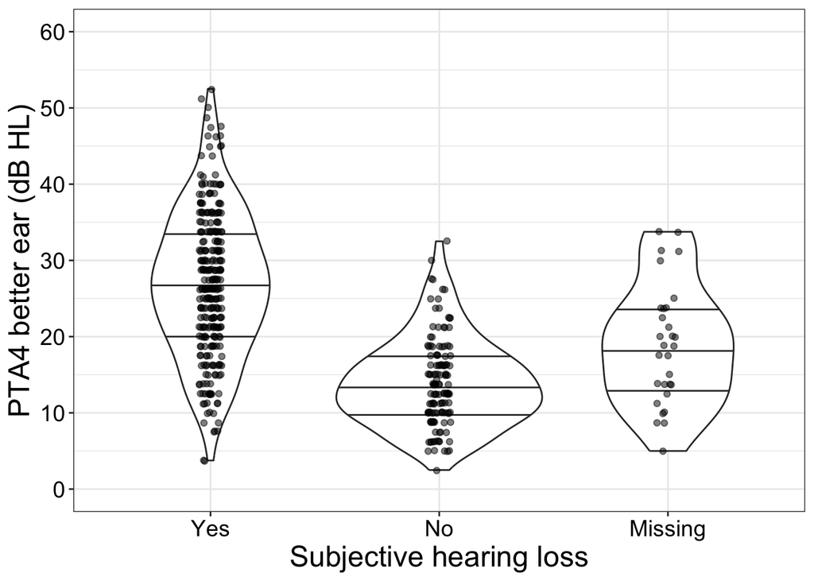

## Regression results

back to top

Outcome: Subjective hearing loss (Yes=1, No=0)

Predictors: 19 sensory and non-sensory variables

Note: Complete cases without imputation: 365 / 527.

```
##
## Call:
## glm(formula = m1_formula, family = "binomial", data = compdata)
##
## Coefficients:
##                          Estimate Std. Error z value       Pr(>|z|)
## (Intercept)              -4.17092    3.03107  -1.376        0.16880
## PTA4_better_ear           0.19225    0.03056   6.292 0.000000000314 ***
## PTA4_asym                 0.14221    0.05386   2.641        0.00828 **
## any_hearing_device       17.81904  914.66434   0.019        0.98446
## SSQ15i_speech            -0.36705    0.12293  -2.986        0.00283 **
## vision_difficulty        -1.50429    1.17053  -1.285        0.19875
## Age                       0.01973    0.03117   0.633        0.52666
## Gender_rec                0.60911    0.42156   1.445        0.14848
## Money_problem             0.40625    0.61148   0.664        0.50645
## Multimorbidity_score      0.08196    0.10195   0.804        0.42146
## CSRQ_mean                 0.10590    0.54823   0.193        0.84682
## Memory_worsening          0.77907    0.38080   2.046        0.04077 *
## Transport_problem        -1.90812    0.93425  -2.042        0.04111 *
## Retired                  -0.52299    0.43049  -1.215        0.22441
## Lives_alone               0.99983    0.51094   1.957        0.05037 .
## Lonely                   -0.41668    0.53421  -0.780        0.43540
## Soc_support               0.29435    0.26633   1.105        0.26906
## Social_network_index      0.27223    0.14692   1.853        0.06389 .
## Soc_participation_freq   -0.33661    0.32964  -1.021        0.30720
## Soc_participation_types  -0.12745    0.15678  -0.813        0.41627
## ---
## Signif. codes:  0 '***' 0.001 '**' 0.01 '*' 0.05 '.' 0.1 ' ' 1
##
## (Dispersion parameter for binomial family taken to be 1)
##
##     Null deviance: 450.09  on 364  degrees of freedom
## Residual deviance: 210.37  on 345  degrees of freedom
## AIC: 250.37
##
## Number of Fisher Scoring iterations: 18
```

## Comparison with Hamalainen et al. results

back to top

Similar findings:  
* Worse PTA, higher asymmetry, self-report more trouble hearing in noise ~ more hearing difficulty/subjective HL  
* Memory (higher PC scores for their sample, subjective worsening memory for our sample), driving/good transport, higher social network index ~ more hearing difficulty/subjective HL

They found these effects, but we did not:  
* Age, male sex, device use, higher multimorbidity

## Variance inflation factor (VIF)

back to top

```
##                         Variance_inflation_factor
## PTA4_better_ear                          1.337164
## PTA4_asym                                1.145848
## any_hearing_device                       1.000000
## SSQ15i_speech                            1.881152
## vision_difficulty                        1.325226
## Age                                      1.796265
## Gender_rec                               1.380735
## Money_problem                            1.525275
## Multimorbidity_score                     1.812161
## CSRQ_mean                                2.509306
## Memory_worsening                         1.205670
## Transport_problem                        1.370644
## Retired                                  1.474025
## Lives_alone                              1.475076
## Lonely                                   1.455911
## Soc_support                              1.643476
## Social_network_index                     1.895890
## Soc_participation_freq                   1.652992
## Soc_participation_types                  2.205669
```

## High-leverage datapoints

back to top

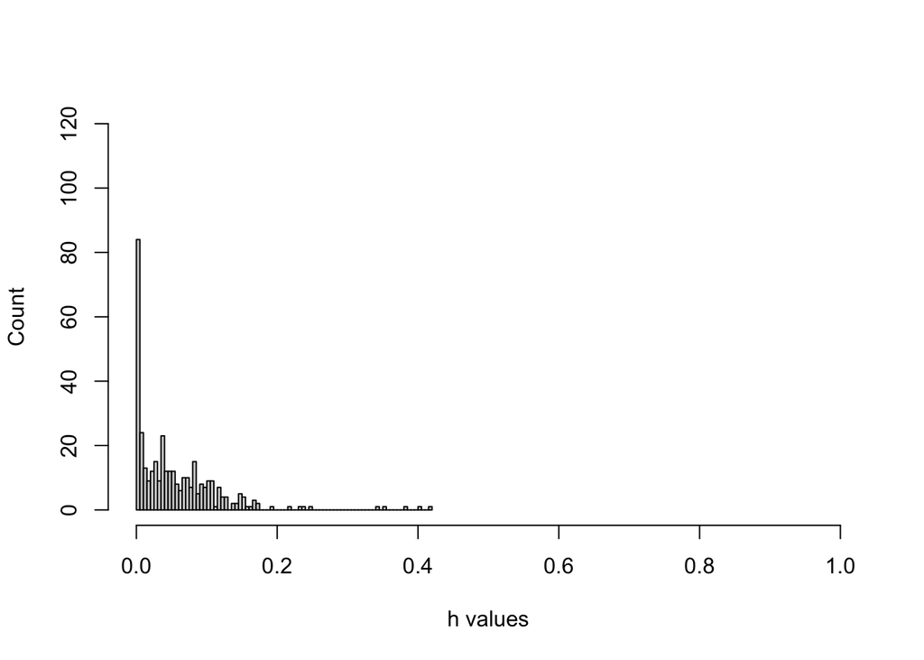